# paleofire: an R package to analyse sedimentary charcoal records from the Global Charcoal Database to reconstruct past biomass burning

Blarquez et al. 2014

We describe a new `R` package, `paleofire`, for analysis and synthesis of charcoal time series, such as those contained in the Global Charcoal Database (GCD), that are used to reconstruct paleofire activity (past biomass burning). `paleofire` is an initiative of the Global Paleofire Working Group core team (www.gpwg.org), whose aim is to encourage the use of sedimentary charcoal series to develop regional-to-global syntheses of paleofire activity, and to enhance access to the GCD data by providing a common research framework. Currently, `paleofire` features are organized into three different parts related to (i) site selection and charcoal series extraction from the GCD; (ii) charcoal data transformation; and (iii) charcoal series compositing and synthesis. We provide a technical description of `paleofire` and describe some new implementations such as the circular block bootstrap procedure. We tested the software using GCDv3 data from eastern North America, and provide examples of interpreting results of regional and global syntheses.

charcoal, fire, biomass burning, databases, `R` statistical language

# Introduction

In the last decade, regional and global syntheses of sedimentary charcoal records have been used to examine broad-scale patterns in palaeofire activity (C. Carcaillet et al. 2002; M. Power et al. 2008; Daniau et al. 2012). The linkages among fire, climate, vegetation and humans at centennial-millennial timescales have likewise been examined using global and regional syntheses (J.R. Marlon et al. 2008; A. A. Ali et al. 2012). Syntheses of charcoal records can also aid the validation and calibration of fire simulations (Flannigan et al. 2001; Pechony and Shindell 2009; Girardin et al. 2013; Brücher et al. 2014). Because fire influences ecosystems at all spatio-temporal scales (ranging from days to centuries and from microsites to biomes), a growing interest in paleofire research has emerged. Additionally, future wildfire regimes may have no analogues from recent decades, and so identifying reference conditions and baselines in the past has become crucial to projecting future wildfire activity (Girardin et al. 2013). Sedimentary charcoal series from individual sites are distributed worldwide, and are increasingly included in the Global Charcoal Database (Power et al. 2010 GCD), which provides the scientific community a global charcoal dataset for research and archiving for sedimentary records of fire (the GCD is available at http://gpwg.org/gpwgdb.html). Syntheses of spatio-temporal changes in fire at global (J.R. Marlon et al. 2008; M. Power et al. 2008; Daniau et al. 2012; J. R. Marlon et al. 2013) and regional (Marlon et al. 2009; S. Mooney et al. 2011; B. Vannière et al. 2011; Power et al. 2013) scales were obtained by applying several analytical steps implemented by a set of Fortran programs (Bartlein, P. J. unpublished). Because these statistical methods are not easily usable or modifiable, the Global Paleofire Working Group core team has developed a package using the open-source `R` statistical programming language. The new package should increase accessibility to paleofire data while providing the fire-science community with new analytical tools that include and extend the previously used functions for GCD data extraction and statistical analysis.  
The aim of this paper is to describe the `paleofire` `R` package that facilitates the analysis of charcoal records contained in the GCD. The `paleofire` package functions are organized into three parts: (i) GCD site selection and data extraction using a variety of criteria (geographic, sedimentary, etc.), (ii) charcoal data transformation, including re-scaling, single-record variance homogenization and nonparametric trend estimation and (iii) data synthesis, including confidence limit estimation using resampling procedures.

# Global Charcoal Database to paleofire data synthesis

The raw charcoal data are accessible with the `data(paleofiredata)` command. The data consist of a seven column data frame containing: (i) site unique identifier, (ii) sample depth, (iii) sample age, (iv) sample charcoal value, (v) sample charcoal unit, (vi) extraction method (sieved charcoal, pollen slide charcoals, etc.) and (vii) sample type unit (influx or concentration). The default setting for the `R` package is to select the preferred units (e.g., concentration or influx values are typically preferred over charcoal-to-pollen ratios if both are available) used in previous analysis (see Daniau et al. 2012 or; M. Power et al. 2008), however `paleofire` allows one to analyse charcoal records with user-defined units or methods (e.g. sieved *vs* pollen slide charcoals, see pfSiteSel and pfTransform functions help for details).

# Technical description of `paleofire`

Here we provide a technical description and several illustrative examples of `paleofire`. The `paleofire` package is written in the `R` scientific computing language (`R` Development Core Team, 2011) and was developed under the `R` 3.0.3 version but remains compatible with `R` >=2.10.0. The functions in `paleofire` are arranged into three groups associated with data selection, charcoal series transformation, and synthesis. We used the S3 method scheme to implement generic plotting and summary functions.

To present some of the `paleofire` capabilities, the examples below use charcoal series from Eastern North America. For additional examples and a detailed overview of individual functions, the reader is referred to the online help available at http://cran.r-project.org/web/packages/paleofire/paleofire.pdf.

## Site selection

Two functions are dedicated to site selection. The first one, `pfInteractive` requires users to interactively draw a polygon on a map to select sites with respect to their geographic location. The function returns a list object containing site names and identifiers that is further used in the following analysis steps and is called using `pfInteractive()`.

```r
library(paleofire)
```

The `pfSiteSel` function is more versatile than `pfInteractive` and has arguments for a variety of user-defined criteria. In the example below we select charcoal series between 30° and 90° latitude and -100° and -50° longitude, and include only those with at least one geochronological (<sup>14</sup>C or <sup>210</sup>Pb dating, tephra layer, etc.) control point each 2500 year.

```r
length(ID$id_site)
```

```
[1] 71
```

Seventy-one sites are selected and stored in the ID object of the class `pfSiteSel`. The summary function associated with the `pfSiteSel` object returns a table (Table SI1) containing site information, including geographic (latitude, longitude and elevation) and chronological descriptors (number of chronological control points, number of samples, minimum and maximum estimated ages). In the example below the `summary` function is applied to the ID object and the `pfSiteSel` function is used to select site records with at least 20 samples.

```r
length(ID$id_site)
```

```
[1] 57
```

The 57 selected sites can be plotted on a map using the generic `plot` function ; a zoom level can be specified using the zoom argument. The use of this function is illustrated in the example below, which is used to construct Figure 1. The `plot` function may also be used to explore the sampling resolution of sites using the `type=chronology` argument.

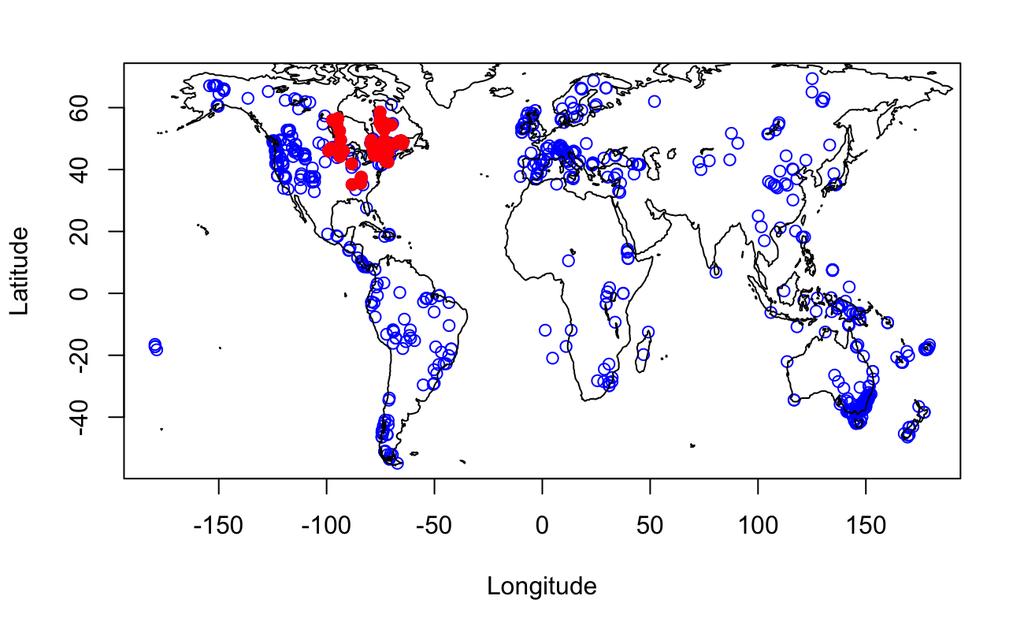

## Data transformation

Charcoal values contained in the GCD can vary widely among and within sites due to multiple factors. For instance, variations in (absolute) charcoal abundances can be related to different analytical methods (i.e. sediment treatment; Tinner and Hu 2003) as well as to unique physiographic site characteristics Jennifer Marlon, Bartlein, and Whitlock (2006). Variations in charcoal values may also be linked to differences in the types of records (pollen slide charcoals, sieved charcoals, charcoal/pollen ratios, Carcaillet et al. 2001). Lastly, differences in the original sample quantities (influx, concentration, percentage) could also contribute to variations in charcoal values. Consequently, transformation and standardization of different charcoal records is a highly recommended step in generating a synthesis. A methodology to standardize charcoal records was proposed by M. Power et al. (2008) and involved a three-step data transformation including a minimax data-rescaling, variance homogenization using Box and Cox (1964) data transformation, and a final rescaling to Z-scores. Using the `pfTransform` function these transformations are done on influx using the following command:

```r
TR1 <- pfTransform(ID, method=c("MinMax","Box-Cox","Z-Score"))
```

```
Loading and preparing data...
Transforming...
Percentage done: 10 20 30 40 50 60 70 80 90 100
```

Note that by default the `pfTransform` function calculates influx for series whose data is given in concentrations, by multiplying concentrations by sediment vertical accretion rate ($cm.yr^{-1}$) calculated using the age-depth model for each record (the `QuantType=NONE` argument can be passed to the `pfTransform` function for keeping original units but it is not recommended). The `method` argument may list single or multiple methods (that are computed in the same order as given in the function), relating to charcoal data transformation or smoothing. The distributions of charcoal values typically have long right tails, and can generally be easily transformed to a symmetrical “normal”-like distribution P. E. Higuera et al. (2011). The transformations we implemented include both the Box and Cox (1964) parametric power transformation technique (default method) and the modified Box-Cox modulus transformation, proposed by John and Draper (1980), which is known to more effectively produce normality in long tailed data, i.e. in the case of charcoal series data presenting numerous zero values. These are accessible through the pfTransform function using the `type=c(BoxCox1964 , JohnDraper)` argument.

The types of filtering (smoothing or compositing) techniques implemented here include running means, median, min, max, quantiles, locally weighted scatter plot smoother (LOESS) and smoothing splines; all these methods take an additional parameter giving the window width for computations (RunWidth argument) or the smoothing parameter in the case of the LOESS or the smoothing-spline methods (span argument). Associated to `pfTransform` users may choose to add their own data to the analysis using the `pfAddData` function that uses the CharAnalysis file type format P. E. Higuera et al. (2009 freely available at https://github.com/phiguera/CharAnalysis), or any file containing charcoal quantities and associated depth and age information as input. In the following example we will add the charcoal data from Senici et al. (2013). The `BasePeriod` argument is used to set the period 200-4000 BP as a base period for the Z-score calculation (M. Power et al. 2008). Note that a minimax data-rescaling step was added after the Box-Cox transformation because Box-Cox transformed series are comparable only if they share identical $\lambda$ values (J.R. Marlon et al. 2008).

```r
download.file(url="http://blarquez.com/public/data/data_cageo.zip",
                destfile="data_cageo.zip")
download.file(url="http://blarquez.com/public/data/data_cageo.zip",
                destfile="data_cageo.zip")
unzip("data_cageo.zip")
mydata=pfAddData(files=c("Ben.csv","Small.csv"),
                   metadata="metadata.csv", type="CharAnalysis")
```

```
incomplete final line found by readTableHeader on 'metadata.csv'
```

```r
mydata=pfAddData(files=c("Ben.csv","Small.csv"),
                   metadata="metadata.csv", type="CharAnalysis")
```

```
incomplete final line found by readTableHeader on 'metadata.csv'
```

```r
TR2 <- pfTransform(ID,add=mydata,BasePeriod=c(200,4000),
                   method=c("MinMax","Box-Cox","MinMax","Z-Score"))
```

```
Loading and preparing data...
Transforming...
Percentage done: 10 20 30 40 50 60 70 80 90 100
```

```r
mydata=pfAddData(files=c("Ben.csv","Small.csv"),
                   metadata="metadata.csv", type="CharAnalysis")
```

```
incomplete final line found by readTableHeader on 'metadata.csv'
```

```r
TR2 <- pfTransform(ID,add=mydata,BasePeriod=c(200,4000),
                   method=c("MinMax","Box-Cox","MinMax","Z-Score"))
```

```
Loading and preparing data...
Transforming...
Percentage done: 10 20 30 40 50 60 70 80 90 100
```

```r
file.remove(c("Ben.csv","Small.csv","data_cageo.zip","metadata.csv"))
```

```
[1] TRUE TRUE TRUE TRUE
```

## Data synthesis and compositing

```r
COMP2 <- pfCompositeLF(TR2, tarAge=seq(-50,12000,20),
                       binhw=10, hw=500, nboot=100)
```

```
Prebinning...
Percentage done: 10 20 30 40 50 60 70 80 90 100
Bootstrapping...
Percentage done: 10 20 30 40 50 60 70 80 90 100
```

The `tarAge` argument is used to define the center of each bin in the prebinning procedure (`binhw` being the prebinning bin half width) and the ages where the LOWESS estimation takes place.

## Confidence intervals

*Option A*  
The confidence intervals for the `pfComposite` function are calculated by bootstrap resampling of the binned charcoal series and calculatiion of the mean for each bin n times, using the argument `nboot` to choose n value (by default nboot=1000). For the `pfCompositeLF` function confidence intervals are calculated by bootstrap resampling the prebinned series (as opposed to individual samples) and then applying the LOWESS curve fitting. This operation is repeated n times and is defined using the argument `nboot`. The confidences intervals are estimated based on the distribution of the bootstrap replicates.

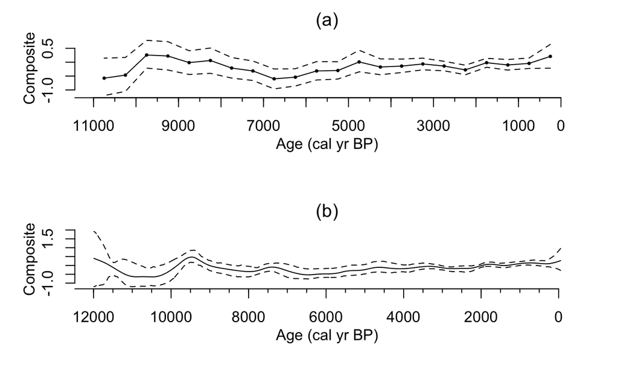

[Composite charcoal series for North Eastern American sites. (a) Composite values and associated confidence intervals using the pfComposite function. (b) Composite values and associated confidence intervals using the pfCompositeLF function (b). Dashed lines correspond to the 97.5th, 2.5th and 95th, 0.5th percentiles respectively.]

*Option B*  
Bootstrapped confidence intervals are usually calculated by resampling the charcoal series with replacement in order to test the sensitivity of the composite record to individual series (or sites, option A). However, because the values in charcoal series are autocorrelated, testing the significance of their temporal variations is not straightforward. Block bootstrap has been proposed to test the significance of changes in stationary time series (Kunsch 1989). Here we implemented a new procedure in the `paleofire` package of “moving” or “circular” block bootstrap, which consists of splitting each charcoal series into $n-b+1$ overlapping blocks of data, where $n$ is sample size and $b$ the block size. These blocks are randomly selected (with replacement) to reconstruct new individual charcoal series that are in turn used to estimate the confidence intervals around the charcoal series composite mean. This procedure may dampen the long-term trends in data, particularly if individual sites record opposing trends. If the observed trend does not exceed the confidence intervals, then there the composite values at that time are not greater than by chance if records are not at all synchronized. However, a composite curve not exceeding the confidence intervals does not exclude the occurrence of important trends in the composite series. This procedure is rather used for testing the significance of local minima or maxima in the composite time series.  
The optimal block size for a given series is given by: $b=2\times(-1/log(\rho))$, where $\rho$ is the lag one autocorrelation coefficient of that series (Adams, Mann, and Ammann 2003).

The circular block bootstrap method is commonly used in Superposed Epoch Analysis, a compositing technique that aims to find the response of a variable to one or multiple particular events, for instance insect outbreaks (Nola et al. 2006 e.g.) or fires (Swetnam 1993 e.g.) using dendrochronological series or paleoecological proxy series (Blarquez and Carcaillet 2010). The `R` implementation follows the Matlab SEA function available at http://blarquez.com that was inspired by Adams, Mann, and Ammann (2003) methodology. The `pfCircular` function is called using the following command and returns an object of class `pfCircular` that can be plotted using the generic plot function:

```r
circboot <- pfCircular(COMP1, b=NULL, nboot=100,
                        conf=c(0.005,0.025,0.975,0.995))
```

```
# of Bootstrap: 10 20 30 40 50 60 70 80 90 100
```

```r
circboot <- pfCircular(COMP1, b=NULL, nboot=100,
                        conf=c(0.005,0.025,0.975,0.995))
```

```
# of Bootstrap: 10 20 30 40 50 60 70 80 90 100
```

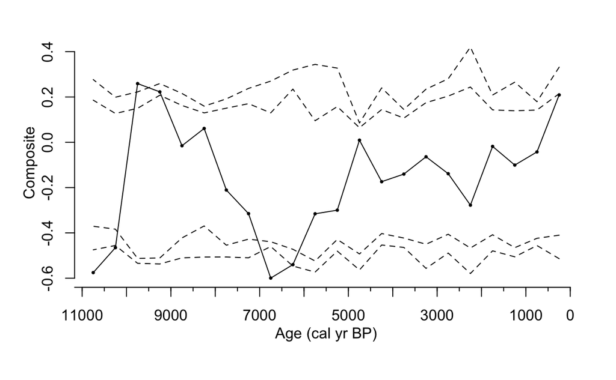

```r
plot(circboot)
```

[Composite mean of charcoal series for Eastern North American sites (black line) and associated confidence intervals estimated using a circular block bootstrap procedure (dashed lines). Dashed lines correspond to the 99.5th, 97.5th, 2.5th and 0.5th bootstrapped percentiles, respectively.]

The `b=NULL` argument indicates that the block size is automatically calculated for each series using the formulation above.